# Homework 3

Kireeti Mantrala

9/26/2022

```r
library(datasets)
```

## Time Series dataset for UKgas

- The data shows gas consumption in the UK from 1960-1986
- The data is divided quarterly in millions of therms.

## Plot for the dataset

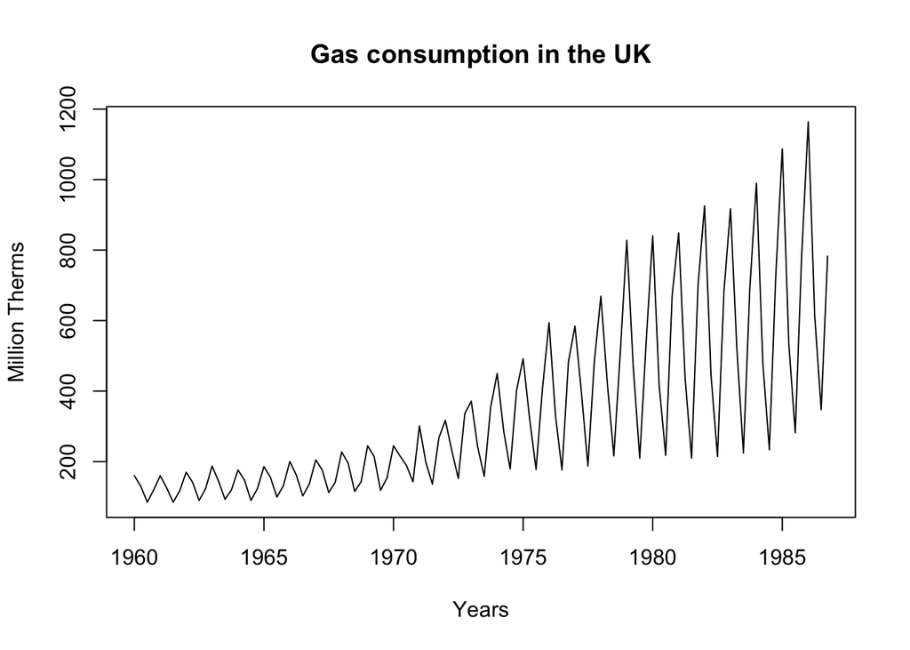

```r
plot(UKgas, main = "Gas consumption in the UK", xlab = "Years", ylab = "Million Therms")
```

- This is the timeseries plot for the dataseries with x-axis showing years and y-axis showing gas consumption in million therms
- The plot is a combination of upward trend with seasonal time series throughout all the quarters.
- The Acf prediction for the above time series plot would be a decreasing trend above the confidence interval along with wavy pattern since the series is both trend and seasonal.

## Autocorrelationfunction for the dataset

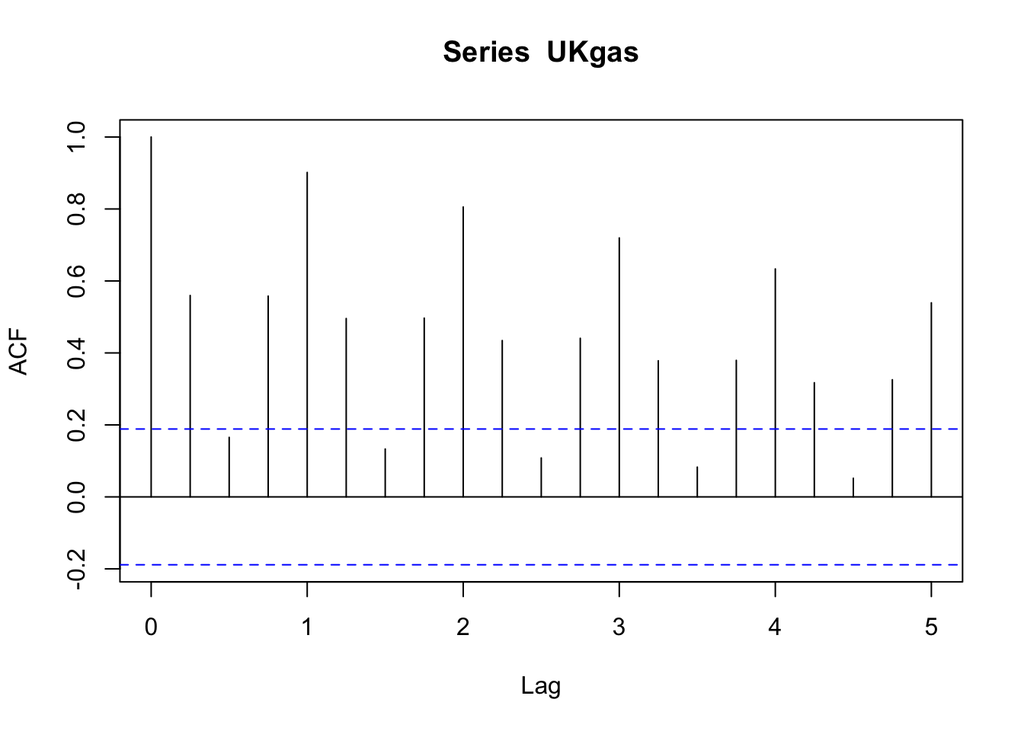

```r
acf(UKgas)
```

- Most of the values are above the confidence interval. Hence, the historical data will make a significant difference in the forecast.
- As predicted the peaks are in the decreasing pattern showing there is a trend in the time series.
- Also, the pattern showns equally wavy nature, showing this also a seasonal time series.

## HoltWinters Filtering

```r
ukhw <- HoltWinters(UKgas)
attributes(ukhw)
```

```
## $names
## [1] "fitted"       "x"            "alpha"        "beta"         "gamma"
## [6] "coefficients" "seasonal"     "SSE"          "call"
##
## $class
## [1] "HoltWinters"
```

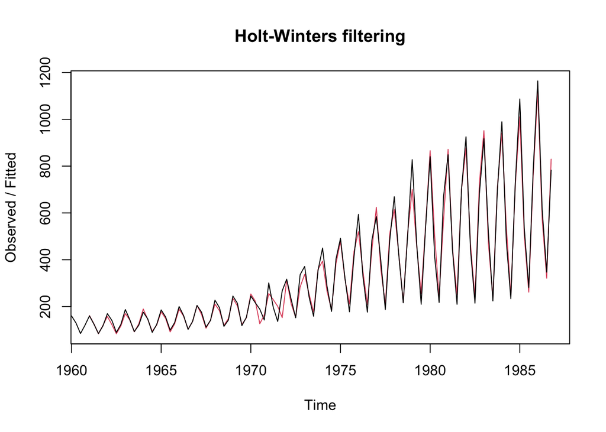

```r
plot(ukhw)
```

- The HoltWinters filtering shows that most of the prediction was accurately aligned, except durning the period from 1970-1973 where there is a minor deviation.

```r
library(forecast)
ukhwf <- forecast(ukhw)
attributes(ukhwf)
```

```
## $names
##  [1] "method"    "model"     "level"     "mean"      "lower"     "upper"
##  [7] "x"         "series"    "fitted"    "residuals"
##
## $class
## [1] "forecast"
```

## Residual Plot

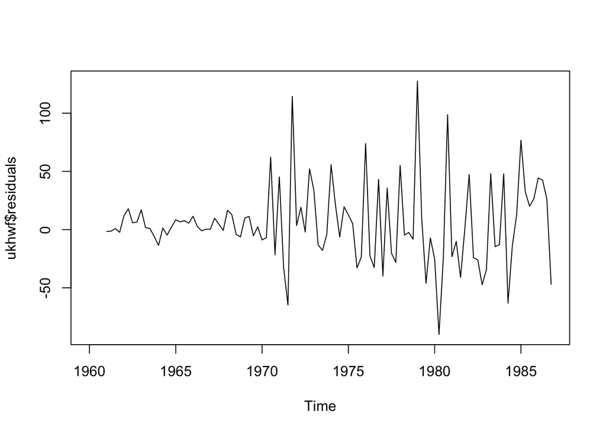

```r
plot(ukhwf$residuals)
```

- The residual plot shows that the residuals are very random and unpredictable.

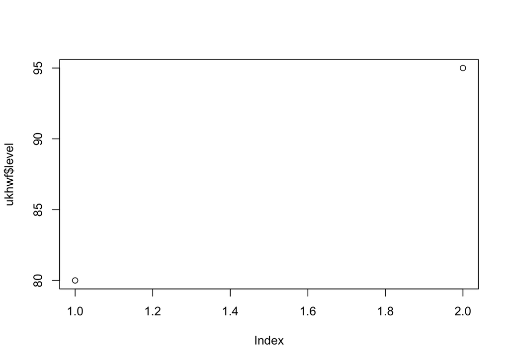

```r
plot(ukhwf$level)
```

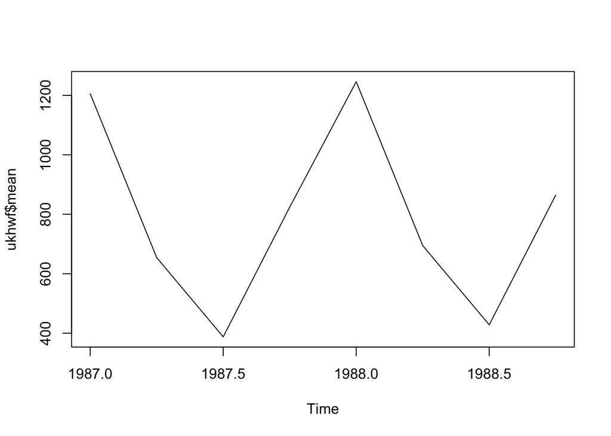

```r
plot(ukhwf$mean)
```

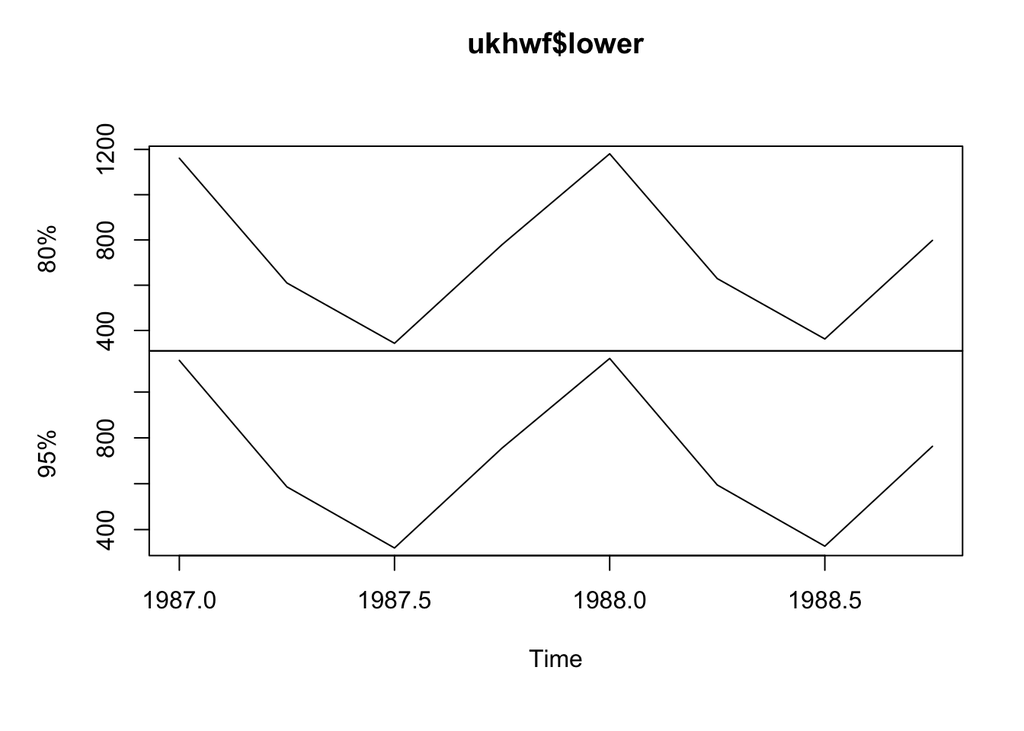

```r
plot(ukhwf$lower)
```

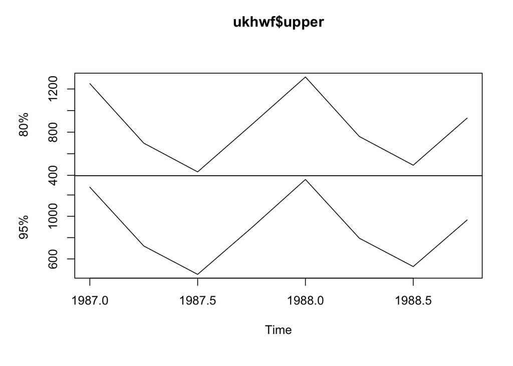

```r
plot(ukhwf$upper)
```

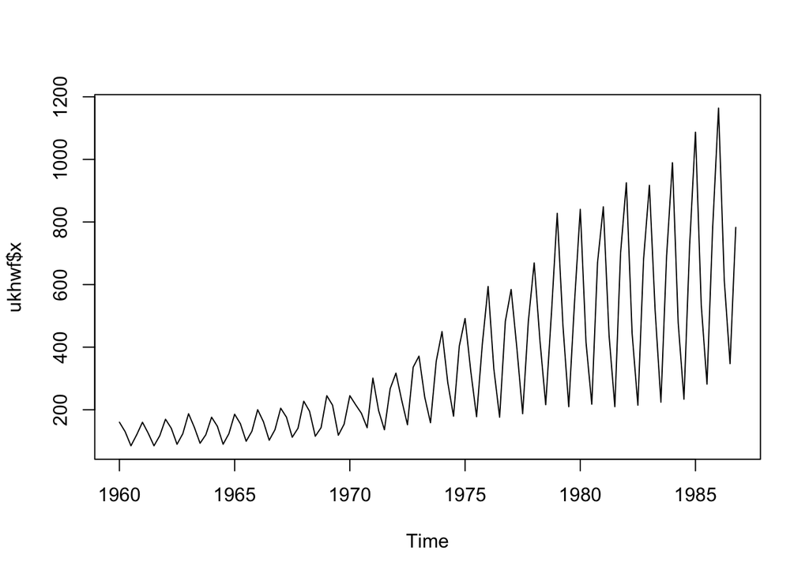

```r
plot(ukhwf$x)
```

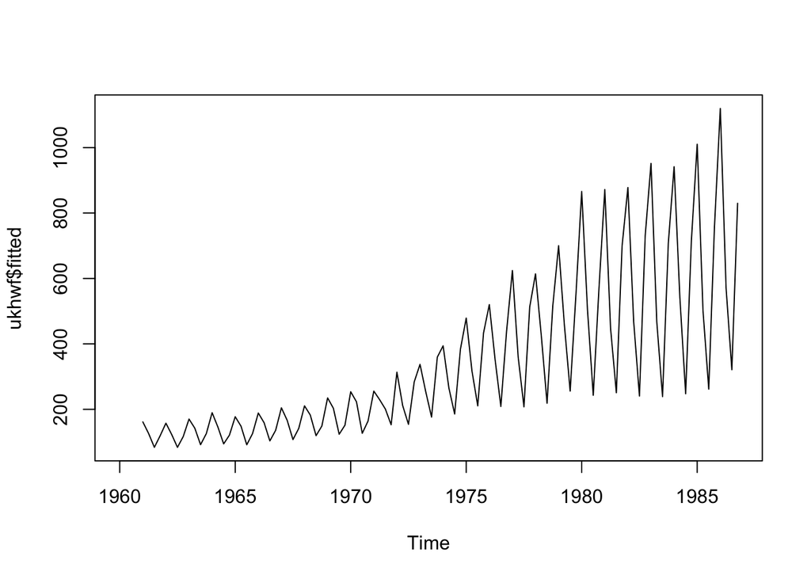

```r
plot(ukhwf$fitted)
```

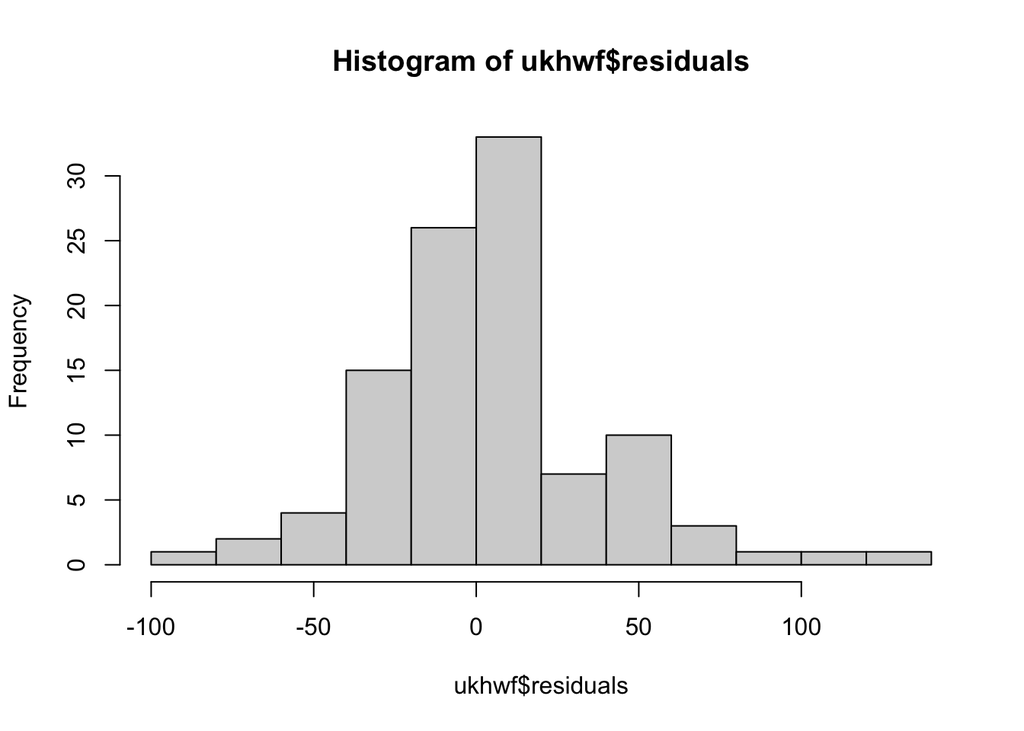

```r
hist(ukhwf$residuals)
```

- The histogram looks vaguly distributed with zero as centre but it appears to have slight deviations and not a perfect uniform distribution.

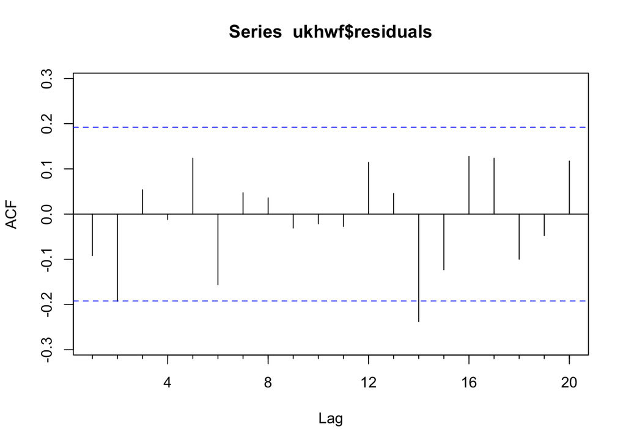

```r
Acf(ukhwf$residuals)
```

- Almost all the bars are within the confidence interval except for one value.

```r
accuracy(ukhwf)
```

```
##                    ME     RMSE      MAE       MPE     MAPE      MASE       ACF1
## Training set 4.818073 34.66147 23.89749 0.2897599 7.359041 0.8488468 -0.0918772
```